# idea1 – Language preference and interest in statistical inference

Varun

## Question (as confirmed in `scripts/analysis-plan.md`)

**Does programming language correlate with students’ interest in statistical inference?**

We are not claiming language preference *causes* interest in statistical inference – more likely both come from the same underlying pull toward the “stats” side vs. the “ML” side of data science. We’re checking whether the two tend to go together, not asserting a causal direction.

## Variables, files, and respondents

| Variable | File | What it is |
| --- | --- | --- |
| `language` | `interest-clean.csv` | R / Python / No preference |
| `areas` | `interest-clean.csv` | multi-select checklist of data science areas (comma-separated); we use the single option “Statistical models and inference, generally” |
| `response_id` | `interest-clean.csv` | respondent id |

Only `interest-clean.csv` is needed – both `language` and `areas` live in the same file, so no join to `background-clean.csv` is required for this question.

**Respondents: n = 49** (the full interest-clean.csv). We checked directly – `language`, `type`, and `areas` all have **zero missing values** in the current data file, so no rows need to be dropped for this question. (Note: an earlier team note referenced 2 respondents, ids 1038/1046, with NA language/type – that was based on an older version of the data; it no longer applies to the current `interest-clean.csv`, confirmed by direct check.)

## Data preparation

1. Build a binary outcome column: did the respondent select “Statistical models and inference, generally” in their `areas` response? (1 = yes, 0 = no)
   - This label contains an internal comma, so if you ever split `areas` into long format for other areas, protect this label first (`str_replace_all` to a comma-free version) before splitting on commas. For this question we only need one label, so we just use `str_detect(areas, fixed("Statistical models and inference"))`, which is safe without any comma-splitting.
2. Set `language` as a factor with reference level `"Python"` (the largest group, n = 22) so model output reads as “relative to Python.”

```r
interest <- read_csv('../../data/interest-clean.csv', show_col_types = FALSE)

d <- interest %>%
  mutate(
    language = factor(language, levels = c('Python', 'R', 'No preference')),
    interested_stat_inference = str_detect(areas, fixed('Statistical models and inference'))
  )

nrow(d)
```

```
## [1] 49
```

```r
count(d, language)
```

```
## # A tibble: 3 × 2
##   language          n
##   <fct>         <int>
## 1 Python           22
## 2 R                11
## 3 No preference    16
```

## Summary / plot

```r
d %>%
  group_by(language) %>%
  summarise(proportion_interested = mean(interested_stat_inference), n = n())
```

```
## # A tibble: 3 × 3
##   language      proportion_interested     n
##   <fct>                         <dbl> <int>
## 1 Python                        0.5      22
## 2 R                             0.818    11
## 3 No preference                 0.688    16
```

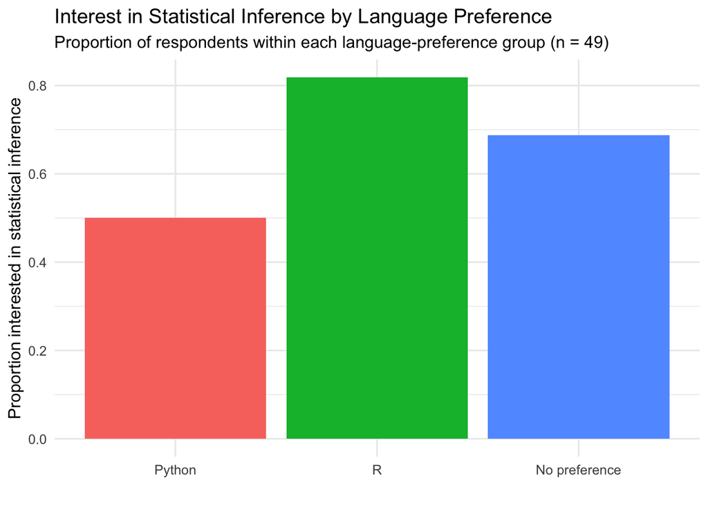

```r
fig <- d %>%
  group_by(language) %>%
  summarise(proportion = mean(interested_stat_inference), n = n()) %>%
  ggplot(aes(x = language, y = proportion, fill = language)) +
  geom_col() +
  labs(title = 'Interest in Statistical Inference by Language Preference',
       subtitle = 'Proportion of respondents within each language-preference group (n = 49)',
       x = '', y = 'Proportion interested in statistical inference', fill = 'Language preference') +
  theme_minimal(base_size = 12) +
  theme(legend.position = 'none')

fig
```

```r
ggsave('../../results/figures/language-vs-statinference.png', fig, width = 6, height = 4.5, dpi = 150)
```

**What it shows:** R-preferring students are the most likely to be interested in statistical inference (81.8%), followed by No preference (68.8%), then Python (50.0%).

## Model: logistic regression

Outcome: interested in statistical inference (0/1). Predictor: `language` (reference = Python). This quantifies the pattern in the figure with an odds ratio and a 95% confidence interval, instead of just comparing bars by eye.

```r
model <- glm(interested_stat_inference ~ language, data = d, family = 'binomial')

model_results <- tidy(model, exponentiate = TRUE, conf.int = TRUE) %>%
  filter(term != '(Intercept)') %>%
  mutate(term = str_remove(term, 'language')) %>%
  select(language_vs_python = term, odds_ratio = estimate,
         ci_low = conf.low, ci_high = conf.high, p.value)

model_results
```

```
## # A tibble: 2 × 5
##   language_vs_python odds_ratio ci_low ci_high p.value
##   <chr>                   <dbl>  <dbl>   <dbl>   <dbl>
## 1 R                        4.50  0.899   34.2   0.0912
## 2 No preference            2.20  0.588    9.01  0.251
```

**Results (reference group = Python, n = 49):**

| Language | Odds ratio | 95% CI | p-value |
| --- | --- | --- | --- |
| R | 4.50 | 0.90 – 34.2 | 0.091 |
| No preference | 2.20 | 0.59 – 9.01 | 0.251 |

**In plain words:** R-preferring students had roughly 4.5x the odds of being interested in statistical inference compared to Python-preferring students. No-preference students had roughly 2.2x the odds. Both point in the expected direction – and the R comparison is close to the conventional significance threshold (p = 0.091, just above 0.05) – but neither formally reaches p < 0.05. The sample is small, especially the R group (n = 11), so the confidence intervals are wide (R’s spans from “barely different,” 0.90, to “very different,” 34.2). Report this as a *trend*, not a *confirmed* effect.

## Key choices made (for the team / report writers)

- **Reference level = Python**, since it’s the largest group (n = 22) – makes every comparison read naturally as “relative to the most common choice.”
- **No rows dropped** – checked directly, `language`/`type`/`areas` have zero missing values in the current data, so all 49 respondents are used.
- **Single area only (“Statistical models and inference”)**, per the team’s narrowed scope in `analysis-plan.md` – we originally explored 3 areas (also Deep learning, NLP) and saw a consistent stats-vs-ML split across all of them; happy to share that broader context if it’s useful for the report’s discussion, but the committed model/figure here is scoped to just the one area.

## For whoever writes the interpretation / report section

- Headline number to quote: **R students ~4.5x the odds of stats-inference interest vs. Python students (p = 0.091, not quite significant at the conventional 0.05 threshold, n = 49)**.
- Raw proportions, if a simpler number is preferred over the odds ratio: R = 81.8% interested, No preference = 68.8%, Python = 50.0%.
- Figure file: `results/figures/language-vs-statinference.png`
- Full code above is self-contained and reproducible (just needs `data/interest-clean.csv`).